# Week 12: Neural Networks — Layers, Signals, and Learning from Examples

# Part 7: Train a feedforward network on Iris (beginner-friendly benchmark)

We compare **multinomial logistic regression** (`nnet::multinom`) with a single-hidden-layer **feedforward network** (`nnet::nnet`). Iris is tiny—expect small gaps—but the pattern mirrors larger projects: hold out a test set, fit models, compare accuracy. Neural nets benefit from **scaled** numeric inputs, so we **center and scale** the four measurement columns using training-set means and SDs before fitting `nnet` (logistic regression is invariant to linear scaling of inputs, so we keep it on raw units for simplicity).

```r
data(iris)
set.seed(MASTER_SEED)
n_train <- floor(0.75 * nrow(iris))
train_idx <- sample(seq_len(nrow(iris)), size = n_train)
iris_train <- iris[train_idx, ]
iris_test <- iris[-train_idx, ]

scale_numeric_like_train <- function(train_df, test_df) {
  nums <- c("Sepal.Length", "Sepal.Width", "Petal.Length", "Petal.Width")
  train_s <- train_df
  test_s <- test_df
  for (v in nums) {
    mu <- mean(train_df[[v]])
    sdv <- stats::sd(train_df[[v]])
    if (!is.finite(sdv) || sdv < 1e-8) sdv <- 1
    train_s[[v]] <- (train_df[[v]] - mu) / sdv
    test_s[[v]] <- (test_df[[v]] - mu) / sdv
  }
  list(train = train_s, test = test_s)
}

iris_scaled <- scale_numeric_like_train(iris_train, iris_test)
iris_train_nn <- iris_scaled$train
iris_test_nn <- iris_scaled$test
```

```r
set.seed(MASTER_SEED)
log_fit <- nnet::multinom(Species ~ ., data = iris_train, trace = FALSE)

set.seed(MASTER_SEED)
nnet_fit <- nnet::nnet(
  Species ~ .,
  data = iris_train_nn,
  size = 10,
  decay = 0.01,
  maxit = 400,
  trace = FALSE,
  linout = FALSE,
  MaxNWts = 8000
)
```

```r
pred_log <- predict(log_fit, iris_test, type = "class")
pred_nn <- predict(nnet_fit, iris_test_nn, type = "class")

acc_log <- mean(pred_log == iris_test$Species)
acc_nn <- mean(pred_nn == iris_test$Species)

cat(sprintf("Hold-out accuracy — multinomial logistic: %.3f\n", acc_log))
```

```
## Hold-out accuracy — multinomial logistic: 0.895
```

```r
cat(sprintf("Hold-out accuracy — nnet (10 hidden units, fixed decay): %.3f\n", acc_nn))
```

```
## Hold-out accuracy — nnet (10 hidden units, fixed decay): 0.895
```

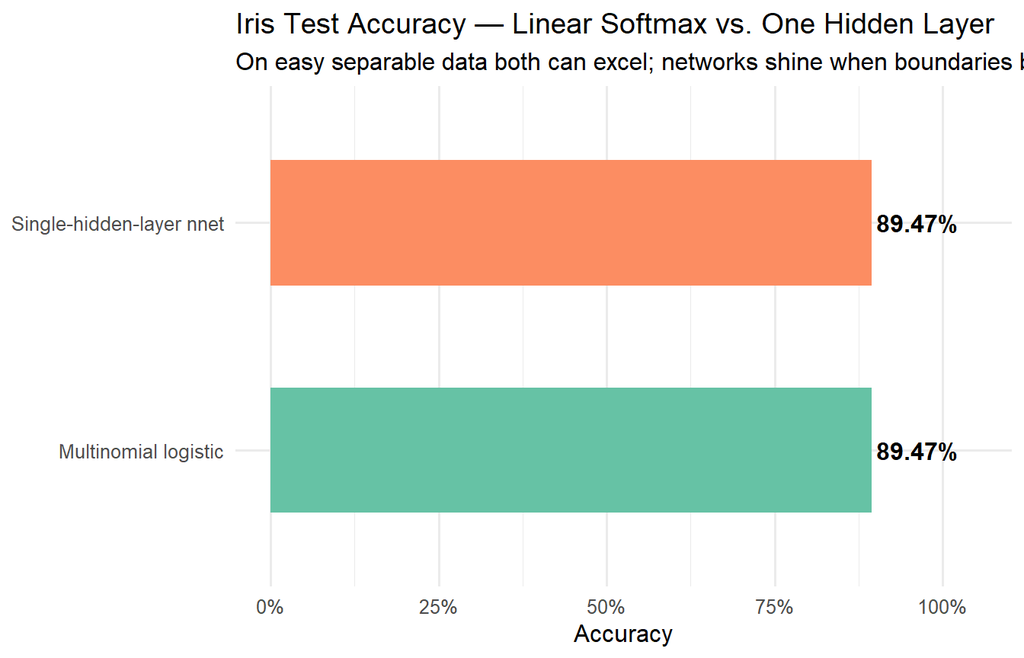

```r
compare_df <- tibble(
  Model = c("Multinomial logistic", "Single-hidden-layer nnet"),
  Accuracy = c(acc_log, acc_nn)
)

ggplot(compare_df, aes(x = reorder(Model, Accuracy), y = Accuracy, fill = Model)) +
  geom_col(width = 0.55) +
  geom_text(aes(label = sprintf("%.2f%%", Accuracy * 100)), hjust = -0.05, fontface = "bold") +
  coord_flip() +
  scale_y_continuous(labels = percent, limits = c(0, 1.05)) +
  scale_fill_brewer(palette = "Set2", guide = "none") +
  labs(
    title = "Iris Test Accuracy — Linear Softmax vs. One Hidden Layer",
    subtitle = "On easy separable data both can excel; networks shine when boundaries bend",
    x = NULL,
    y = "Accuracy"
  ) +
  theme_minimal(base_size = 12)
```

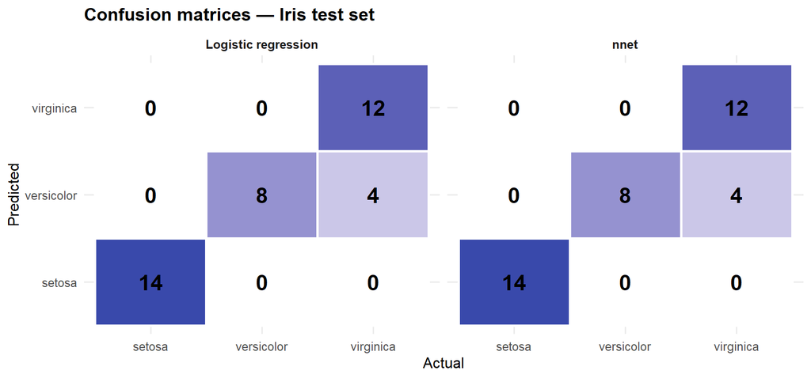

```r
cm_both <- bind_rows(
  mutate(as_tibble(table(Predicted = pred_log, Actual = iris_test$Species)), model = "Logistic regression"),
  mutate(as_tibble(table(Predicted = pred_nn, Actual = iris_test$Species)), model = "nnet")
) %>%
  mutate(model = factor(model, levels = c("Logistic regression", "nnet")))

ggplot(cm_both, aes(x = Actual, y = Predicted, fill = n)) +
  geom_tile(color = "white", size = 1) +
  geom_text(aes(label = n), fontface = "bold", size = 6) +
  scale_fill_gradient(low = "white", high = "#3949AB") +
  facet_wrap(~model, nrow = 1) +
  labs(title = "Confusion matrices — Iris test set", x = "Actual", y = "Predicted") +
  theme_minimal(base_size = 12) +
  theme(
    legend.position = "none",
    plot.title = element_text(face = "bold"),
    strip.text = element_text(face = "bold")
  )
```

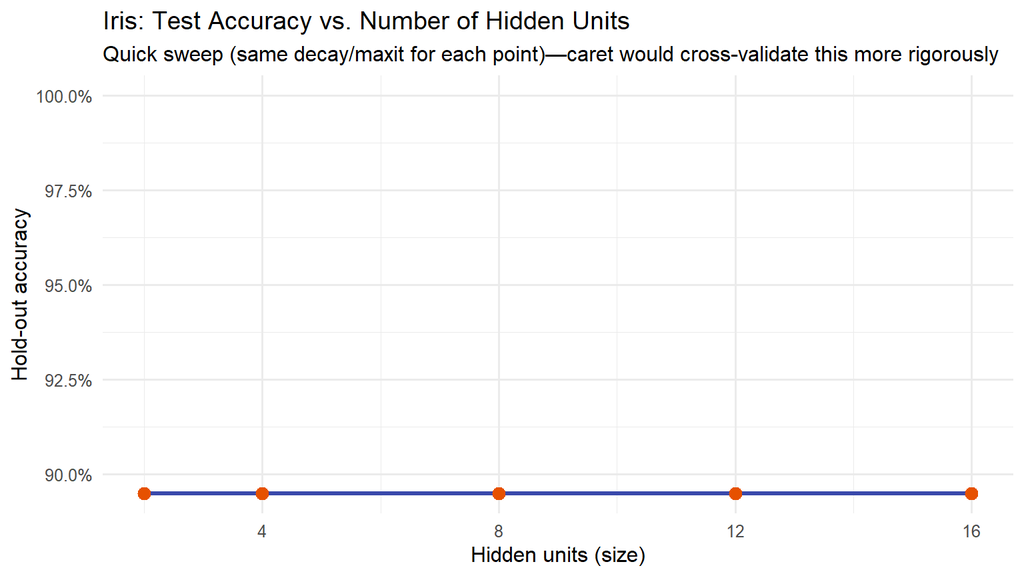

```r
sizes_try <- c(2L, 4L, 8L, 12L, 16L)

acc_by_size <- map_dbl(sizes_try, function(sz) {
  set.seed(MASTER_SEED)
  fit_sz <- nnet::nnet(
    Species ~ .,
    data = iris_train_nn,
    size = sz,
    decay = 0.02,
    maxit = 350,
    trace = FALSE,
    linout = FALSE,
    MaxNWts = 12000
  )
  mean(predict(fit_sz, iris_test_nn, type = "class") == iris_test$Species)
})

curve_sz <- tibble(hidden_units = sizes_try, test_accuracy = acc_by_size)

ggplot(curve_sz, aes(x = hidden_units, y = test_accuracy)) +
  geom_line(size = 1.1, color = "#3949AB") +
  geom_point(size = 3, color = "#E65100") +
  scale_y_continuous(labels = scales::percent, limits = c(NA, 1)) +
  labs(
    title = "Iris: Test Accuracy vs. Number of Hidden Units",
    subtitle = "Quick sweep (same decay/maxit for each point)—caret would cross-validate this more rigorously",
    x = "Hidden units (size)",
    y = "Hold-out accuracy"
  ) +
  theme_minimal(base_size = 12)
```

# Part 8: Capacity, data hunger, and interpretability

Practical reminders for beginners

| Topic | Guidance |
| --- | --- |
| Flexibility | Hidden layers can bend boundaries; depth stacks bends. |
| Data needs | Large nets crave large, representative labeled sets [1]. |
| Training cost | Many weights → longer training; GPUs help big models. |
| Interpretability | Weights are hard to narrate—treat as high-accuracy black boxes unless using diagnostics. |
| Overfitting risk | Match capacity to data; use validation curves, dropout (in deep libs), weight decay. |

# Knowledge check

**Question 1:** In one sentence, what does a hidden layer do?**

**Answer:** It transforms the original features through learned weighted sums and nonlinear activations so the output layer can separate patterns that were not linearly separable in raw space.

**Question 2:** Why must activations be nonlinear?**

**Answer:** Composing only linear layers stays linear overall—no new bending power. Nonlinear activations let stacked layers approximate curved boundaries (see XOR).

**Question 3:** Forward vs. backward pass?**

**Answer:** Forward computes predictions with current weights; backward propagates loss derivatives to adjust each weight efficiently [1], [2].

**Question 5:** When might logistic regression be enough?**

**Answer:** When classes are roughly linearly separable and interpretability matters more than squeezing the last points of accuracy—simple baselines first.

# Summary

1. Neural networks chain **weighted sums + biases + activations**; depth adds representational flexibility.
2. **Forward propagation** is multiply-add-activate layer by layer; **loss** scores mistakes.
3. **Backpropagation + gradient descent** adjust weights to reduce loss; **learning rate** matters.
4. Nonlinear activations unlock patterns like **XOR**; linear models cannot bend enough alone.
5. In R, `nnet`/`caret` trains compact feedforward models; match **capacity** to data and watch **generalisation**.

# References

[1] GeeksforGeeks, “Neural Networks — A beginner’s guide,” 2026. [Online]. Available: https://www.geeksforgeeks.org/deep-learning/neural-networks-a-beginners-guide/

[2] V. Zhou, “Machine Learning for Beginners: An Introduction to Neural Networks,” victorzhou.com, updated Jan. 13, 2026. [Online]. Available: https://victorzhou.com/blog/intro-to-neural-networks/

[3] Roozbeh Sadeghian, *ANLY530 Lecture 13 — Neural Networks* (PowerPoint slides), Week 12 course materials.

[4] Z. Huang, “seedhash: Deterministic Seed Generation from String Inputs Using MD5 Hashing,” R package, 2026. [Online]. Available: https://github.com/roozbeh412/seedhash